# Practical Machine Learning Course Project

Kyle Tan

Tuesday, September 15, 2015

# Executive Summary

The goal of this project is to predict the manner (A/B/C/D/E) in which participants did Dumbbell Biceps Curl. The data taken from 4 sensors recording 6 young participants performing the Dumbbell Biceps Curl is used as predictors. Cross Validation on Training/Test set will be used to assess the expected mean Out-Of-Sample error for 2 methods (CART vs RF).

Data is based on (http://groupware.les.inf.puc-rio.br/har) found in section on Weight Lifting Exercises Dataset.

# Summary of Methodology

1. Get Data
2. Clean Data
3. Partition Data (Cross Validation K-Fold, K=4)
4. Methodology 1: CART
5. Methodology 2: Random Forest
6. Model Selection
7. Apply Model on Test Data

# Reproduceability

To ensure reproduceability, the following library and seed must be loaded

```r
library(caret)
library(rpart)
library(rattle)
library(randomForest)
set.seed(88888)
```

# Import Data

We import the dataset downloaded from the URLs: -Training: https://d396qusza40orc.cloudfront.net/predmachlearn/pml-training.csv -Testing: https://d396qusza40orc.cloudfront.net/predmachlearn/pml-testing.csv

```r
training <- read.csv("pml-training.csv", na.strings=c("NA","","#DIV/0!"))
testing <- read.csv("pml-testing.csv", na.strings=c("NA","","#DIV/0!"))
```

# Basic Data Exploration

We did some basic data exploration. Initial round of visual inspection suggests that some columns have too many missing values.

```r
str(training)
summary(training)
```

# Clean Data

Clean #1: We removed 100 columns with >60% missing values.

```r
getNaCol <- function(x, thres) { # custom function to find NA columns
        index <- c()
        percent <- c()
        noObs <- dim(x)[1]
        for (i in 1:dim(x)[2]) { # loop thru all cols
                missing <- sum( is.na(x[,i]) ) / noObs
                if ( missing >= thres ) {
                        index <- append(index,i) # col w missing % > thres
                        percent <- missing
                }
        }
        return(rbind(index,percent))
}
naIndex <- getNaCol(training,0.6) #>60% missing values
training_clean1 <- training[-naIndex[1,]]
```

Clean #2: We next removed 1 near zero variance column.

```r
zeroVarIndex <- nearZeroVar(training_clean1)
training_clean2 <- training_clean1[-zeroVarIndex]
```

Clean #3: Finally we dropped first 6 columns that are visually inspected and determined to have no predictive power.

```r
training_cleanf <- training_clean2[,-c(1:6)]
```

Clean Test Data: We did the same cleaning for our test data.

```r
testing_clean1 <- testing[-naIndex[1,]]
testing_clean2 <- testing_clean1[-zeroVarIndex]
testing_cleanf <- testing_clean2[,-c(1:6)]
```

```r
cbind(names(training_cleanf),names(training_cleanf))
```

```
##       [,1]                   [,2]
##  [1,] "roll_belt"            "roll_belt"
##  [2,] "pitch_belt"           "pitch_belt"
##  [3,] "yaw_belt"             "yaw_belt"
##  [4,] "total_accel_belt"     "total_accel_belt"
##  [5,] "gyros_belt_x"         "gyros_belt_x"
##  [6,] "gyros_belt_y"         "gyros_belt_y"
##  [7,] "gyros_belt_z"         "gyros_belt_z"
##  [8,] "accel_belt_x"         "accel_belt_x"
##  [9,] "accel_belt_y"         "accel_belt_y"
## [10,] "accel_belt_z"         "accel_belt_z"
## [11,] "magnet_belt_x"        "magnet_belt_x"
## [12,] "magnet_belt_y"        "magnet_belt_y"
## [13,] "magnet_belt_z"        "magnet_belt_z"
## [14,] "roll_arm"             "roll_arm"
```

[output cut: 39 more lines]

# Parition Data

We chose to perform K-Fold (K=4) Cross Validation by dividing the training set into 4.

```r
inTrain <- createFolds(training_cleanf$classe, k=4, list=TRUE, returnTrain=TRUE)
sapply(inTrain,length)
```

```
## Fold1 Fold2 Fold3 Fold4
## 14716 14716 14716 14718
```

```r
# Training/Validation set 1
training1 <- training_cleanf[inTrain$Fold1,]
validation1 <- training_cleanf[-inTrain$Fold1,]
# Training/Validation set 2
training2 <- training_cleanf[inTrain$Fold2,]
validation2 <- training_cleanf[-inTrain$Fold2,]
# Training/Validation set 3
training3 <- training_cleanf[inTrain$Fold3,]
validation3 <- training_cleanf[-inTrain$Fold3,]
# Training/Validation set 4
training4 <- training_cleanf[inTrain$Fold4,]
validation4 <- training_cleanf[-inTrain$Fold4,]
```

# Methodology 1 - CART Model

## Modelling - CART

We first apply CART Model to our training data using the RPART function. Here we use “classe” as the predicate, and all other variables as potential predictors.

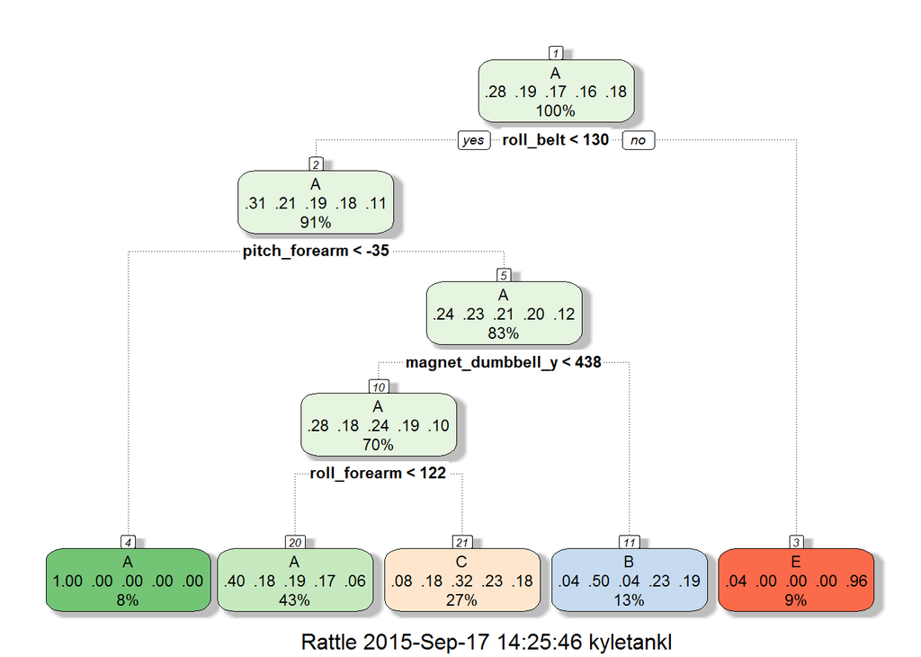

```r
# CART Model - Training set 1
modFitRp1 <- train(classe ~ ., data=training1, method="rpart")
fancyRpartPlot(modFitRp1$finalModel)
```

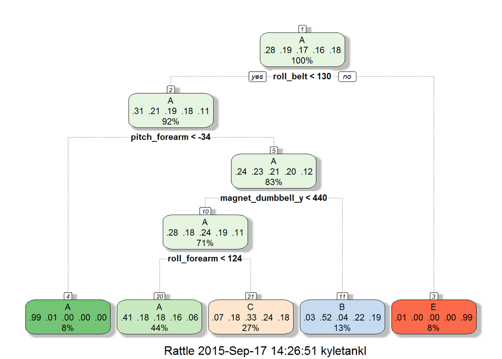

```r
# CART Model - Training set 2
modFitRp2 <- train(classe ~ ., data=training2, method="rpart")
fancyRpartPlot(modFitRp2$finalModel)
```

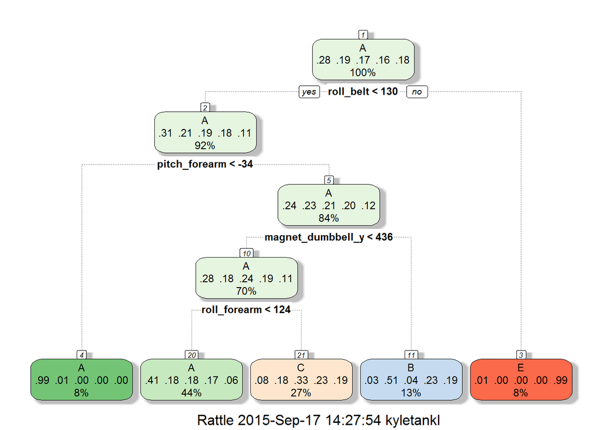

```r
# CART Model - Training set 3
modFitRp3 <- train(classe ~ ., data=training3, method="rpart")
fancyRpartPlot(modFitRp3$finalModel)
```

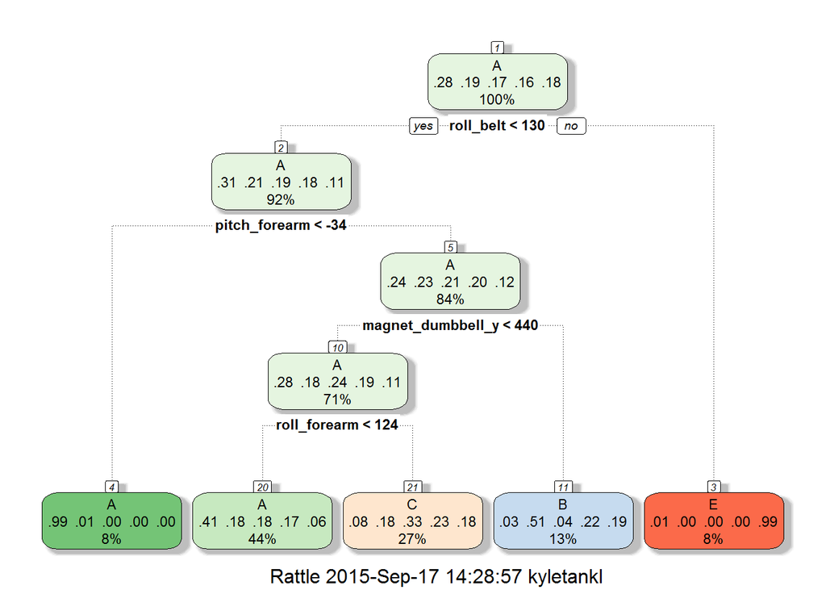

```r
# CART Model - Training set 1
modFitRp4 <- train(classe ~ ., data=training4, method="rpart")
fancyRpartPlot(modFitRp4$finalModel)
```

## Results - CART

The 4 CART models are largely similar splitting the tree on roll_belt, pitch_forearm, magnet_dumbbell_y, roll_forearm.

We test the model accuracy on their respective validation (hold out) data set.

```r
# CART Model - Validation set 1
predictRp1 <- predict(modFitRp1, newdata=validation1)
cMatrixRp1 <- confusionMatrix(predictRp1, validation1$classe)
accuracy_Rp1 <- cMatrixRp1$overall["Accuracy"]
# CART Model - Validation set 2
predictRp2 <- predict(modFitRp2, newdata=validation2)
cMatrixRp2 <- confusionMatrix(predictRp2, validation2$classe)
accuracy_Rp2 <- cMatrixRp2$overall["Accuracy"]
# CART Model - Validation set 3
predictRp3 <- predict(modFitRp3, newdata=validation3)
cMatrixRp3 <- confusionMatrix(predictRp3, validation3$classe)
accuracy_Rp3 <- cMatrixRp3$overall["Accuracy"]
# CART Model - Validation set 4
predictRp4 <- predict(modFitRp4, newdata=validation4)
cMatrixRp4 <- confusionMatrix(predictRp4, validation4$classe)
accuracy_Rp4 <- cMatrixRp4$overall["Accuracy"]
```

The CART Model method’s expected Accuracy is low at 49.5%. It is however, important to compare this result to the baseline of 20% if a naive model of uniform distribution (i.e. guess A/B/C/D/E with equal probability) is used. This model has >2 times better accuracy than the baseline model.

```r
x=cbind(accuracy_Rp1,accuracy_Rp2,accuracy_Rp3,accuracy_Rp4)
cbind(x,expected_Rp=mean(x))
```

```
##          accuracy_Rp1 accuracy_Rp2 accuracy_Rp3 accuracy_Rp4 expected_Rp
## Accuracy    0.5057073    0.4885854    0.4965349    0.4887847   0.4949031
```

# Methodology 2 - Random Forest (RF) Model

## Modelling - RF

We next apply RF Model to our training data using the RF function. Here we use “classe” as the predicate, and all other variables as potential predictors.

```r
# RF Model - Training set 1
modFitRf1 <- randomForest(classe ~ ., data=training1)
print(modFitRf1)
```

```
##
## Call:
##  randomForest(formula = classe ~ ., data = training1)
##                Type of random forest: classification
##                      Number of trees: 500
## No. of variables tried at each split: 7
##
##         OOB estimate of  error rate: 0.46%
## Confusion matrix:
##      A    B    C    D    E class.error
## A 4179    4    1    0    1 0.001433692
## B   11 2833    4    0    0 0.005266854
## C    0   13 2552    1    0 0.005455963
## D    0    0   28 2384    0 0.011608624
## E    0    0    1    4 2700 0.001848429
```

```r
# RF Model - Training set 2
modFitRf2 <- randomForest(classe ~ ., data=training2)
print(modFitRf2)
```

```
##
## Call:
##  randomForest(formula = classe ~ ., data = training2)
##                Type of random forest: classification
##                      Number of trees: 500
## No. of variables tried at each split: 7
##
##         OOB estimate of  error rate: 0.43%
## Confusion matrix:
##      A    B    C    D    E  class.error
## A 4181    1    0    1    2 0.0009557945
## B   12 2830    6    0    0 0.0063202247
## C    0   13 2553    0    0 0.0050662510
## D    0    0   20 2390    2 0.0091210614
## E    0    0    1    6 2698 0.0025878004
```

```r
# RF Model - Training set 3
modFitRf3 <- randomForest(classe ~ ., data=training3)
print(modFitRf3)
```

```
##
## Call:
##  randomForest(formula = classe ~ ., data = training3)
##                Type of random forest: classification
##                      Number of trees: 500
## No. of variables tried at each split: 7
##
##         OOB estimate of  error rate: 0.48%
## Confusion matrix:
##      A    B    C    D    E  class.error
## A 4183    2    0    0    0 0.0004778973
## B   15 2827    5    0    0 0.0070249385
## C    0   13 2552    2    0 0.0058433970
## D    0    0   23 2386    3 0.0107794362
## E    0    0    3    5 2697 0.0029574861
```

```r
# RF Model - Training set 1
modFitRf4 <- randomForest(classe ~ ., data=training4)
print(modFitRf4)
```

```
##
## Call:
##  randomForest(formula = classe ~ ., data = training4)
##                Type of random forest: classification
##                      Number of trees: 500
## No. of variables tried at each split: 7
##
##         OOB estimate of  error rate: 0.46%
## Confusion matrix:
##      A    B    C    D    E  class.error
## A 4184    1    0    0    0 0.0002389486
## B    8 2834    6    0    0 0.0049157303
## C    0   18 2548    1    0 0.0074016362
## D    0    0   21 2388    3 0.0099502488
## E    0    0    1    8 2697 0.0033259424
```

## Results - RF

The 4 RF models are perfomring quite well on the training set from the low error rate in the each confusion Matrix.

We test the model accuracy on their respective validation (hold out) data set.

```r
# RF Model - Validation set 1
predictRf1 <- predict(modFitRf1, newdata=validation1)
cMatrixRf1 <- confusionMatrix(predictRf1, validation1$classe)
accuracy_Rf1 <- cMatrixRf1$overall["Accuracy"]
# RF Model - Validation set 2
predictRf2 <- predict(modFitRf2, newdata=validation2)
cMatrixRf2 <- confusionMatrix(predictRf2, validation2$classe)
accuracy_Rf2 <- cMatrixRf2$overall["Accuracy"]
# RF Model - Validation set 3
predictRf3 <- predict(modFitRf3, newdata=validation3)
cMatrixRf3 <- confusionMatrix(predictRf3, validation3$classe)
accuracy_Rf3 <- cMatrixRf3$overall["Accuracy"]
# RF Model - Validation set 4
predictRf4 <- predict(modFitRf4, newdata=validation4)
cMatrixRf4 <- confusionMatrix(predictRf4, validation4$classe)
accuracy_Rf4 <- cMatrixRf4$overall["Accuracy"]
```

The RF Model method’s expected Accuracy is 99.5%, which is > double the expected Accuracy for CART.

```r
y=cbind(accuracy_Rf1,accuracy_Rf2,accuracy_Rf3,accuracy_Rf4)
cbind(y,expected_Rf=mean(y))
```

```
##          accuracy_Rf1 accuracy_Rf2 accuracy_Rf3 accuracy_Rf4 expected_Rf
## Accuracy    0.9944965    0.9961272    0.9959234      0.99531   0.9954643
```

# Model Selection

The highest accuracy is achieved by RF methodology (99.5%) compared to CART methodology (49.5%). From the 4 RF models, we chose Model #2 with the highest accuracy of 99.6%.

```r
print(accuracy_Rf2)
```

```
##  Accuracy
## 0.9961272
```

# Apply Model on Test Data

Finally, we apply our chosen model (RF model #2) to the out-of-sample Test data to get the predicted outcome:

```r
predictF <-  predict(modFitRf2, newdata=testing_cleanf)
print(predictF)
```

```
##  1  2  3  4  5  6  7  8  9 10 11 12 13 14 15 16 17 18 19 20
##  B  A  B  A  A  E  D  B  A  A  B  C  B  A  E  E  A  B  B  B
## Levels: A B C D E
```

And this generates the files for submission

```r
pml_write_files = function(x){
  n = length(x)
  for(i in 1:n){
    filename = paste0("problem_id_",i,".txt")
    write.table(x[i],file=filename,quote=FALSE,row.names=FALSE,col.names=FALSE)
  }
}
pml_write_files(predictF)
```